# Irene Summary

## Demographic information

| Characteristic | N | control, N = 181 | intervention, N = 181 | chi-square/t-statistic | p-value |
| --- | --- | --- | --- | --- | --- |
| age | 36 | 34.17 ± 4.79 (28 - 45) | 37.50 ± 5.63 (30 - 50) | -1.9 | 0.064 |
| gender | 36 |  |  |  |  |
| female |  | 18 (100%) | 18 (100%) |  |  |
| work_r1 | 36 |  |  | 10.7 | 0.005 |
| full_time |  | 8 (44%) | 0 (0%) |  |  |
| part_time |  | 2 (11%) | 2 (11%) |  |  |
| self_employed |  | 8 (44%) | 16 (89%) |  |  |
| shift_work |  | 0 (0%) | 0 (0%) |  |  |
| housewife |  | 0 (0%) | 0 (0%) |  |  |
| unemployed |  | 0 (0%) | 0 (0%) |  |  |
| work_r2 | 36 |  |  | 7.9 | 0.005 |
| full_time |  | 8 (44%) | 0 (0%) |  |  |
| part_time_self_employed |  | 10 (56%) | 18 (100%) |  |  |
| marriage_r1 | 36 |  |  | 4.5 | 0.106 |
| married |  | 16 (89%) | 11 (61%) |  |  |
| stable |  | 1 (5.6%) | 6 (33%) |  |  |
| separate |  | 1 (5.6%) | 1 (5.6%) |  |  |
| divorce |  | 0 (0%) | 0 (0%) |  |  |
| widowed |  | 0 (0%) | 0 (0%) |  |  |
| marriage_r2 | 36 |  |  | 0.0 | >0.999 |
| married_stable |  | 17 (94%) | 17 (94%) |  |  |
| separate_divorce |  | 1 (5.6%) | 1 (5.6%) |  |  |
| academic_r1 | 36 |  |  | 5.3 | 0.070 |
| primary_or_below |  | 1 (5.6%) | 3 (17%) |  |  |
| s1_s3 |  | 9 (50%) | 13 (72%) |  |  |
| s4_s6 |  | 8 (44%) | 2 (11%) |  |  |
| post_secondary |  | 0 (0%) | 0 (0%) |  |  |
| degree |  | 0 (0%) | 0 (0%) |  |  |
| master_or_above |  | 0 (0%) | 0 (0%) |  |  |
| academic_r2 | 36 |  |  | 0.3 | 0.596 |
| primary_or_below |  | 1 (5.6%) | 3 (17%) |  |  |
| secondary |  | 17 (94%) | 15 (83%) |  |  |
| income_r1 | 36 |  |  | 12.0 | 0.002 |
| 0_10000 |  | 6 (33%) | 15 (83%) |  |  |
| 10001_20000 |  | 4 (22%) | 3 (17%) |  |  |
| 20001_30000 |  | 8 (44%) | 0 (0%) |  |  |
| income_r2 | 36 |  |  | 7.9 | 0.005 |
| 0_20000 |  | 10 (56%) | 18 (100%) |  |  |
| 20001_40000 |  | 8 (44%) | 0 (0%) |  |  |
| child | 36 |  |  | 0.7 | 0.721 |
| 1_child |  | 12 (67%) | 14 (78%) |  |  |
| 2_child |  | 5 (28%) | 3 (17%) |  |  |
| 3_child_or_above |  | 1 (5.6%) | 1 (5.6%) |  |  |
| medicine | 36 |  |  | 0.1 | 0.737 |
| no |  | 9 (50%) | 7 (39%) |  |  |
| yes |  | 9 (50%) | 11 (61%) |  |  |

1Mean ± SD (Range); n (%)

## Measurement

### Table

| Characteristic | N | control, N = 181 | intervention, N = 181 | t-statistic | p-value |
| --- | --- | --- | --- | --- | --- |
| pss | 36 | 26.78 ± 6.38 (17 - 37) | 29.44 ± 5.65 (14 - 39) | -1.3 | 0.193 |
| par_ss | 36 | 67.44 ± 10.19 (48 - 82) | 74.50 ± 9.41 (60 - 90) | -2.2 | 0.038 |
| who | 36 | 72.28 ± 12.86 (51 - 90) | 73.44 ± 16.49 (35 - 106) | -0.2 | 0.814 |
| impq | 36 | 93.72 ± 7.75 (80 - 110) | 92.78 ± 8.30 (71 - 102) | 0.4 | 0.726 |
| swan | 36 | 32.72 ± 15.18 (-8 - 50) | 19.56 ± 19.15 (-12 - 50) | 2.3 | 0.029 |

1Mean ± SD (Range)

## Data analysis

### Table

| Group | Characteristic | Beta | SE1 | 95% CI1 | p-value |
| --- | --- | --- | --- | --- | --- |
| pss | (Intercept) | 26.8 | 1.452 | 23.9, 29.6 |  |
|  | group |  |  |  |  |
|  | control | — | — | — |  |
|  | intervention | 2.67 | 2.053 | -1.36, 6.69 | 0.200 |
|  | time_point |  |  |  |  |
|  | 0 | — | — | — |  |
|  | 1 | 0.833 | 0.994 | -1.11, 2.78 | 0.405 |
|  | 2 | 0.278 | 0.994 | -1.67, 2.23 | 0.781 |
|  | group * time_point |  |  |  |  |
|  | intervention * 1 | -4.78 | 1.406 | -7.53, -2.02 | 0.001 |
|  | intervention * 2 | -5.00 | 1.406 | -7.76, -2.24 | 0.001 |
|  | Pseudo R square | 0.057 |  |  |  |
| par_ss | (Intercept) | 67.4 | 2.650 | 62.2, 72.6 |  |
|  | group |  |  |  |  |
|  | control | — | — | — |  |
|  | intervention | 7.06 | 3.748 | -0.291, 14.4 | 0.065 |
|  | time_point |  |  |  |  |
|  | 0 | — | — | — |  |
|  | 1 | 0.000 | 2.327 | -4.56, 4.56 | 1.00 |
|  | 2 | -4.94 | 2.327 | -9.50, -0.384 | 0.037 |
|  | group * time_point |  |  |  |  |
|  | intervention * 1 | -3.67 | 3.290 | -10.1, 2.78 | 0.269 |
|  | intervention * 2 | -0.278 | 3.290 | -6.73, 6.17 | 0.933 |
|  | Pseudo R square | 0.096 |  |  |  |
| who | (Intercept) | 72.3 | 3.310 | 65.8, 78.8 |  |
|  | group |  |  |  |  |
|  | control | — | — | — |  |
|  | intervention | 1.17 | 4.681 | -8.01, 10.3 | 0.805 |
|  | time_point |  |  |  |  |
|  | 0 | — | — | — |  |
|  | 1 | 0.611 | 1.244 | -1.83, 3.05 | 0.625 |
|  | 2 | -0.444 | 1.244 | -2.88, 1.99 | 0.722 |
|  | group * time_point |  |  |  |  |
|  | intervention * 1 | 7.06 | 1.759 | 3.61, 10.5 | 0.000 |
|  | intervention * 2 | 8.00 | 1.759 | 4.55, 11.4 | 0.000 |
|  | Pseudo R square | 0.076 |  |  |  |
| impq | (Intercept) | 93.7 | 1.956 | 89.9, 97.6 |  |
|  | group |  |  |  |  |
|  | control | — | — | — |  |
|  | intervention | -0.944 | 2.766 | -6.37, 4.48 | 0.735 |
|  | time_point |  |  |  |  |
|  | 0 | — | — | — |  |
|  | 1 | -0.444 | 0.999 | -2.40, 1.51 | 0.658 |
|  | 2 | -0.222 | 0.999 | -2.18, 1.74 | 0.825 |
|  | group * time_point |  |  |  |  |
|  | intervention * 1 | 1.67 | 1.413 | -1.10, 4.44 | 0.242 |
|  | intervention * 2 | 8.11 | 1.413 | 5.34, 10.9 | 0.000 |
|  | Pseudo R square | 0.097 |  |  |  |
| swan | (Intercept) | 32.7 | 3.960 | 25.0, 40.5 |  |
|  | group |  |  |  |  |
|  | control | — | — | — |  |
|  | intervention | -13.2 | 5.601 | -24.1, -2.19 | 0.024 |
|  | time_point |  |  |  |  |
|  | 0 | — | — | — |  |
|  | 1 | -1.56 | 1.532 | -4.56, 1.45 | 0.314 |
|  | 2 | 1.61 | 1.532 | -1.39, 4.61 | 0.297 |
|  | group * time_point |  |  |  |  |
|  | intervention * 1 | -6.22 | 2.167 | -10.5, -1.97 | 0.005 |
|  | intervention * 2 | -10.8 | 2.167 | -15.1, -6.59 | 0.000 |
|  | Pseudo R square | 0.259 |  |  |  |

1SE = Standard Error, CI = Confidence Interval

### Text

**pss**

We fitted a linear mixed model (estimated using REML and nloptwrap optimizer) to predict pss with group and time_point (formula: pss ~ 1 + group + time_point + group * time_point). The model included code as random effect (formula: ~1 | code). The model’s total explanatory power is substantial (conditional R2 = 0.78) and the part related to the fixed effects alone (marginal R2) is of 0.06. The model’s intercept, corresponding to group = control and time_point = 0, is at 26.78 (95% CI [23.93, 29.62], t(100) = 18.44, p < .001). Within this model:

- The effect of group [intervention] is statistically non-significant and positive (beta = 2.67, 95% CI [-1.36, 6.69], t(100) = 1.30, p = 0.194; Std. beta = 0.43, 95% CI [-0.22, 1.08])
- The effect of time point [1] is statistically non-significant and positive (beta = 0.83, 95% CI [-1.11, 2.78], t(100) = 0.84, p = 0.402; Std. beta = 0.13, 95% CI [-0.18, 0.45])
- The effect of time point [2] is statistically non-significant and positive (beta = 0.28, 95% CI [-1.67, 2.23], t(100) = 0.28, p = 0.780; Std. beta = 0.04, 95% CI [-0.27, 0.36])
- The interaction effect of time point [1] on group [intervention] is statistically significant and negative (beta = -4.78, 95% CI [-7.53, -2.02], t(100) = -3.40, p < .001; Std. beta = -0.77, 95% CI [-1.21, -0.33])
- The interaction effect of time point [2] on group [intervention] is statistically significant and negative (beta = -5.00, 95% CI [-7.76, -2.24], t(100) = -3.56, p < .001; Std. beta = -0.81, 95% CI [-1.25, -0.36])

Standardized parameters were obtained by fitting the model on a standardized version of the dataset. 95% Confidence Intervals (CIs) and p-values were computed using a Wald normal distribution approximation.

**par_ss**

We fitted a linear mixed model (estimated using REML and nloptwrap optimizer) to predict par_ss with group and time_point (formula: par_ss ~ 1 + group + time_point + group * time_point). The model included code as random effect (formula: ~1 | code). The model’s total explanatory power is substantial (conditional R2 = 0.65) and the part related to the fixed effects alone (marginal R2) is of 0.10. The model’s intercept, corresponding to group = control and time_point = 0, is at 67.44 (95% CI [62.25, 72.64], t(100) = 25.45, p < .001). Within this model:

- The effect of group [intervention] is statistically non-significant and positive (beta = 7.06, 95% CI [-0.29, 14.40], t(100) = 1.88, p = 0.060; Std. beta = 0.61, 95% CI [-0.03, 1.24])
- The effect of time point [1] is statistically non-significant and negative (beta = -1.20e-13, 95% CI [-4.56, 4.56], t(100) = -5.15e-14, p > .999; Std. beta = -1.13e-17, 95% CI [-0.39, 0.39])
- The effect of time point [2] is statistically significant and negative (beta = -4.94, 95% CI [-9.50, -0.38], t(100) = -2.13, p = 0.034; Std. beta = -0.43, 95% CI [-0.82, -0.03])
- The interaction effect of time point [1] on group [intervention] is statistically non-significant and negative (beta = -3.67, 95% CI [-10.12, 2.78], t(100) = -1.11, p = 0.265; Std. beta = -0.32, 95% CI [-0.87, 0.24])
- The interaction effect of time point [2] on group [intervention] is statistically non-significant and negative (beta = -0.28, 95% CI [-6.73, 6.17], t(100) = -0.08, p = 0.933; Std. beta = -0.02, 95% CI [-0.58, 0.53])

Standardized parameters were obtained by fitting the model on a standardized version of the dataset. 95% Confidence Intervals (CIs) and p-values were computed using a Wald normal distribution approximation.

**who**

We fitted a linear mixed model (estimated using REML and nloptwrap optimizer) to predict who with group and time_point (formula: who ~ 1 + group + time_point + group * time_point). The model included code as random effect (formula: ~1 | code). The model’s total explanatory power is substantial (conditional R2 = 0.93) and the part related to the fixed effects alone (marginal R2) is of 0.08. The model’s intercept, corresponding to group = control and time_point = 0, is at 72.28 (95% CI [65.79, 78.76], t(100) = 21.84, p < .001). Within this model:

- The effect of group [intervention] is statistically non-significant and positive (beta = 1.17, 95% CI [-8.01, 10.34], t(100) = 0.25, p = 0.803; Std. beta = 0.08, 95% CI [-0.56, 0.72])
- The effect of time point [1] is statistically non-significant and positive (beta = 0.61, 95% CI [-1.83, 3.05], t(100) = 0.49, p = 0.623; Std. beta = 0.04, 95% CI [-0.13, 0.21])
- The effect of time point [2] is statistically non-significant and negative (beta = -0.44, 95% CI [-2.88, 1.99], t(100) = -0.36, p = 0.721; Std. beta = -0.03, 95% CI [-0.20, 0.14])
- The interaction effect of time point [1] on group [intervention] is statistically significant and positive (beta = 7.06, 95% CI [3.61, 10.50], t(100) = 4.01, p < .001; Std. beta = 0.49, 95% CI [0.25, 0.74])
- The interaction effect of time point [2] on group [intervention] is statistically significant and positive (beta = 8.00, 95% CI [4.55, 11.45], t(100) = 4.55, p < .001; Std. beta = 0.56, 95% CI [0.32, 0.80])

Standardized parameters were obtained by fitting the model on a standardized version of the dataset. 95% Confidence Intervals (CIs) and p-values were computed using a Wald normal distribution approximation.

**impq**

We fitted a linear mixed model (estimated using REML and nloptwrap optimizer) to predict impq with group and time_point (formula: impq ~ 1 + group + time_point + group * time_point). The model included code as random effect (formula: ~1 | code). The model’s total explanatory power is substantial (conditional R2 = 0.88) and the part related to the fixed effects alone (marginal R2) is of 0.10. The model’s intercept, corresponding to group = control and time_point = 0, is at 93.72 (95% CI [89.89, 97.56], t(100) = 47.91, p < .001). Within this model:

- The effect of group [intervention] is statistically non-significant and negative (beta = -0.94, 95% CI [-6.37, 4.48], t(100) = -0.34, p = 0.733; Std. beta = -0.11, 95% CI [-0.74, 0.52])
- The effect of time point [1] is statistically non-significant and negative (beta = -0.44, 95% CI [-2.40, 1.51], t(100) = -0.44, p = 0.656; Std. beta = -0.05, 95% CI [-0.28, 0.18])
- The effect of time point [2] is statistically non-significant and negative (beta = -0.22, 95% CI [-2.18, 1.74], t(100) = -0.22, p = 0.824; Std. beta = -0.03, 95% CI [-0.25, 0.20])
- The interaction effect of time point [1] on group [intervention] is statistically non-significant and positive (beta = 1.67, 95% CI [-1.10, 4.44], t(100) = 1.18, p = 0.238; Std. beta = 0.19, 95% CI [-0.13, 0.52])
- The interaction effect of time point [2] on group [intervention] is statistically significant and positive (beta = 8.11, 95% CI [5.34, 10.88], t(100) = 5.74, p < .001; Std. beta = 0.95, 95% CI [0.62, 1.27])

Standardized parameters were obtained by fitting the model on a standardized version of the dataset. 95% Confidence Intervals (CIs) and p-values were computed using a Wald normal distribution approximation.

**swan**

We fitted a linear mixed model (estimated using REML and nloptwrap optimizer) to predict swan with group and time_point (formula: swan ~ 1 + group + time_point + group * time_point). The model included code as random effect (formula: ~1 | code). The model’s total explanatory power is substantial (conditional R2 = 0.94) and the part related to the fixed effects alone (marginal R2) is of 0.26. The model’s intercept, corresponding to group = control and time_point = 0, is at 32.72 (95% CI [24.96, 40.48], t(100) = 8.26, p < .001). Within this model:

- The effect of group [intervention] is statistically significant and negative (beta = -13.17, 95% CI [-24.14, -2.19], t(100) = -2.35, p = 0.019; Std. beta = -0.69, 95% CI [-1.26, -0.11])
- The effect of time point [1] is statistically non-significant and negative (beta = -1.56, 95% CI [-4.56, 1.45], t(100) = -1.02, p = 0.310; Std. beta = -0.08, 95% CI [-0.24, 0.08])
- The effect of time point [2] is statistically non-significant and positive (beta = 1.61, 95% CI [-1.39, 4.61], t(100) = 1.05, p = 0.293; Std. beta = 0.08, 95% CI [-0.07, 0.24])
- The interaction effect of time point [1] on group [intervention] is statistically significant and negative (beta = -6.22, 95% CI [-10.47, -1.97], t(100) = -2.87, p = 0.004; Std. beta = -0.32, 95% CI [-0.55, -0.10])
- The interaction effect of time point [2] on group [intervention] is statistically significant and negative (beta = -10.83, 95% CI [-15.08, -6.59], t(100) = -5.00, p < .001; Std. beta = -0.56, 95% CI [-0.79, -0.34])

Standardized parameters were obtained by fitting the model on a standardized version of the dataset. 95% Confidence Intervals (CIs) and p-values were computed using a Wald normal distribution approximation.

## Likelihood ratio tests

| outcome | model | npar | AIC | BIC | logLik | deviance | Chisq | Df | p |
| --- | --- | --- | --- | --- | --- | --- | --- | --- | --- |
| pss | null | 3 | 651.934 | 659.980 | -322.967 | 645.934 |  |  |  |
| pss | random | 8 | 637.999 | 659.456 | -310.999 | 621.999 | 23.935 | 5 | 0.000 |
| par_ss | null | 3 | 803.512 | 811.558 | -398.756 | 797.512 |  |  |  |
| par_ss | random | 8 | 799.217 | 820.674 | -391.608 | 783.217 | 14.295 | 5 | 0.014 |
| who | null | 3 | 765.974 | 774.021 | -379.987 | 759.974 |  |  |  |
| who | random | 8 | 734.014 | 755.471 | -359.007 | 718.014 | 41.960 | 5 | 0.000 |
| impq | null | 3 | 706.028 | 714.074 | -350.014 | 700.028 |  |  |  |
| impq | random | 8 | 662.981 | 684.438 | -323.490 | 646.981 | 53.047 | 5 | 0.000 |
| swan | null | 3 | 814.983 | 823.029 | -404.491 | 808.983 |  |  |  |
| swan | random | 8 | 776.845 | 798.303 | -380.423 | 760.845 | 48.137 | 5 | 0.000 |

## Post hoc analysis

### Table

| outcome | time | control n | control estimate | control within es | control within p | treatment n | treatment estimate | treatment within es | treatment within p | between p | between es |
| --- | --- | --- | --- | --- | --- | --- | --- | --- | --- | --- | --- |
| pss | 0 | 18 | 26.8 ± 6.2 |  |  | 18 | 29.4 ± 6.2 |  |  | 0.200 | -0.894 |
| pss | 1 | 18 | 27.6 ± 6.2 | -0.279 | 0.810 | 18 | 25.5 ± 6.2 | 1.323 | 0.000 | 0.309 | 0.708 |
| pss | 2 | 18 | 27.1 ± 6.2 | -0.093 | 1.000 | 18 | 24.7 ± 6.2 | 1.583 | 0.000 | 0.262 | 0.782 |
| par_ss | 0 | 18 | 67.4 ± 11.2 |  |  | 18 | 74.5 ± 11.2 |  |  | 0.065 | -1.011 |
| par_ss | 1 | 18 | 67.4 ± 11.2 | 0.000 | 1.000 | 18 | 70.8 ± 11.2 | 0.525 | 0.239 | 0.370 | -0.486 |
| par_ss | 2 | 18 | 62.5 ± 11.2 | 0.708 | 0.074 | 18 | 69.3 ± 11.2 | 0.748 | 0.056 | 0.076 | -0.971 |
| who | 0 | 18 | 72.3 ± 14.0 |  |  | 18 | 73.4 ± 14.0 |  |  | 0.805 | -0.313 |
| who | 1 | 18 | 72.9 ± 14.0 | -0.164 | 1.000 | 18 | 81.1 ± 14.0 | -2.054 | 0.000 | 0.087 | -2.203 |
| who | 2 | 18 | 71.8 ± 14.0 | 0.119 | 1.000 | 18 | 81.0 ± 14.0 | -2.024 | 0.000 | 0.058 | -2.456 |
| impq | 0 | 18 | 93.7 ± 8.3 |  |  | 18 | 92.8 ± 8.3 |  |  | 0.735 | 0.315 |
| impq | 1 | 18 | 93.3 ± 8.3 | 0.148 | 1.000 | 18 | 94.0 ± 8.3 | -0.408 | 0.451 | 0.795 | -0.241 |
| impq | 2 | 18 | 93.5 ± 8.3 | 0.074 | 1.000 | 18 | 100.7 ± 8.3 | -2.633 | 0.000 | 0.013 | -2.392 |
| swan | 0 | 18 | 32.7 ± 16.8 |  |  | 18 | 19.6 ± 16.8 |  |  | 0.024 | 2.864 |
| swan | 1 | 18 | 31.2 ± 16.8 | 0.338 | 0.627 | 18 | 11.8 ± 16.8 | 1.692 | 0.000 | 0.001 | 4.217 |
| swan | 2 | 18 | 34.3 ± 16.8 | -0.350 | 0.594 | 18 | 10.3 ± 16.8 | 2.006 | 0.000 | 0.000 | 5.220 |

### Between group

**pss**

*1st*

t(46.95) = 1.30, p = 0.200, Cohen d = -0.89, 95% CI (-1.46 to 6.80)

*2st*

t(46.95) = -1.03, p = 0.309, Cohen d = 0.71, 95% CI (-6.24 to 2.02)

*3rd*

t(46.95) = -1.14, p = 0.262, Cohen d = 0.78, 95% CI (-6.46 to 1.80)

**par_ss**

*1st*

t(58.10) = 1.88, p = 0.065, Cohen d = -1.01, 95% CI (-0.45 to 14.56)

*2st*

t(58.10) = 0.90, p = 0.370, Cohen d = -0.49, 95% CI (-4.11 to 10.89)

*3rd*

t(58.10) = 1.81, p = 0.076, Cohen d = -0.97, 95% CI (-0.73 to 14.28)

**who**

*1st*

t(37.40) = 0.25, p = 0.805, Cohen d = -0.31, 95% CI (-8.31 to 10.65)

*2st*

t(37.40) = 1.76, p = 0.087, Cohen d = -2.20, 95% CI (-1.26 to 17.70)

*3rd*

t(37.40) = 1.96, p = 0.058, Cohen d = -2.46, 95% CI (-0.31 to 18.65)

**impq**

*1st*

t(40.60) = -0.34, p = 0.735, Cohen d = 0.32, 95% CI (-6.53 to 4.64)

*2st*

t(40.60) = 0.26, p = 0.795, Cohen d = -0.24, 95% CI (-4.87 to 6.31)

*3rd*

t(40.60) = 2.59, p = 0.013, Cohen d = -2.39, 95% CI (1.58 to 12.75)

**swan**

*1st*

t(37.61) = -2.35, p = 0.024, Cohen d = 2.86, 95% CI (-24.51 to -1.82)

*2st*

t(37.61) = -3.46, p = 0.001, Cohen d = 4.22, 95% CI (-30.73 to -8.05)

*3rd*

t(37.61) = -4.29, p = 0.000, Cohen d = 5.22, 95% CI (-35.34 to -12.66)

### Within treatment group

**pss**

*1st vs 2st*

t(68.00) = -3.97, p = 0.000, Cohen d = NA, 95% CI (-5.93 to -1.96)

*1st vs 3rd*

t(68.00) = -4.75, p = 0.000, Cohen d = NA, 95% CI (-6.71 to -2.74)

**par_ss**

*1st vs 2st*

t(68.00) = -1.58, p = 0.239, Cohen d = NA, 95% CI (-8.31 to 0.98)

*1st vs 3rd*

t(68.00) = -2.24, p = 0.056, Cohen d = NA, 95% CI (-9.87 to -0.58)

**who**

*1st vs 2st*

t(68.00) = 6.16, p = 0.000, Cohen d = NA, 95% CI (5.18 to 10.15)

*1st vs 3rd*

t(68.00) = 6.07, p = 0.000, Cohen d = NA, 95% CI (5.07 to 10.04)

**impq**

*1st vs 2st*

t(68.00) = 1.22, p = 0.451, Cohen d = NA, 95% CI (-0.77 to 3.22)

*1st vs 3rd*

t(68.00) = 7.90, p = 0.000, Cohen d = NA, 95% CI (5.90 to 9.88)

**swan**

*1st vs 2st*

t(68.00) = -5.08, p = 0.000, Cohen d = NA, 95% CI (-10.84 to -4.72)

*1st vs 3rd*

t(68.00) = -6.02, p = 0.000, Cohen d = NA, 95% CI (-12.28 to -6.16)

### Within control group

**pss**

*1st vs 2st*

t(68.00) = 0.84, p = 0.810, Cohen d = NA, 95% CI (-1.15 to 2.82)

*1st vs 3rd*

t(68.00) = 0.28, p = 1.000, Cohen d = NA, 95% CI (-1.71 to 2.26)

**par_ss**

*1st vs 2st*

t(68.00) = -0.00, p = 1.000, Cohen d = NA, 95% CI (-4.64 to 4.64)

*1st vs 3rd*

t(68.00) = -2.13, p = 0.074, Cohen d = NA, 95% CI (-9.59 to -0.30)

**who**

*1st vs 2st*

t(68.00) = 0.49, p = 1.000, Cohen d = NA, 95% CI (-1.87 to 3.09)

*1st vs 3rd*

t(68.00) = -0.36, p = 1.000, Cohen d = NA, 95% CI (-2.93 to 2.04)

**impq**

*1st vs 2st*

t(68.00) = -0.44, p = 1.000, Cohen d = NA, 95% CI (-2.44 to 1.55)

*1st vs 3rd*

t(68.00) = -0.22, p = 1.000, Cohen d = NA, 95% CI (-2.22 to 1.77)

**swan**

*1st vs 2st*

t(68.00) = -1.02, p = 0.627, Cohen d = NA, 95% CI (-4.61 to 1.50)

*1st vs 3rd*

t(68.00) = 1.05, p = 0.594, Cohen d = NA, 95% CI (-1.45 to 4.67)

### Plot

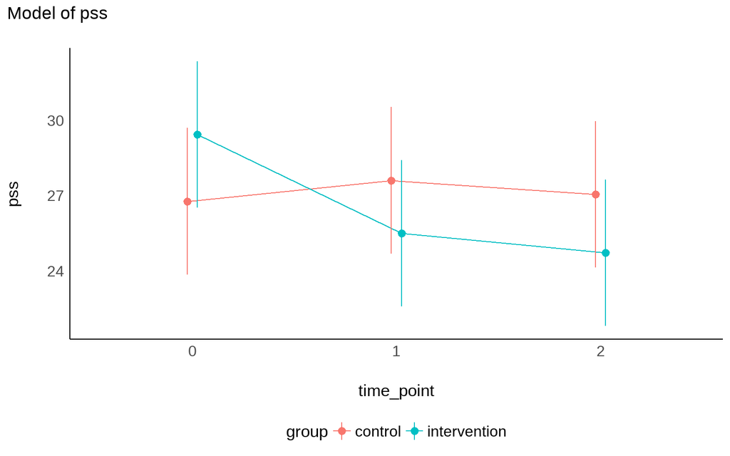

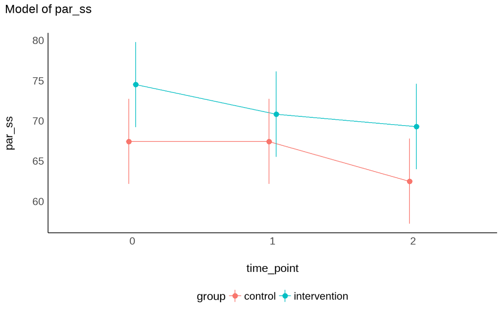

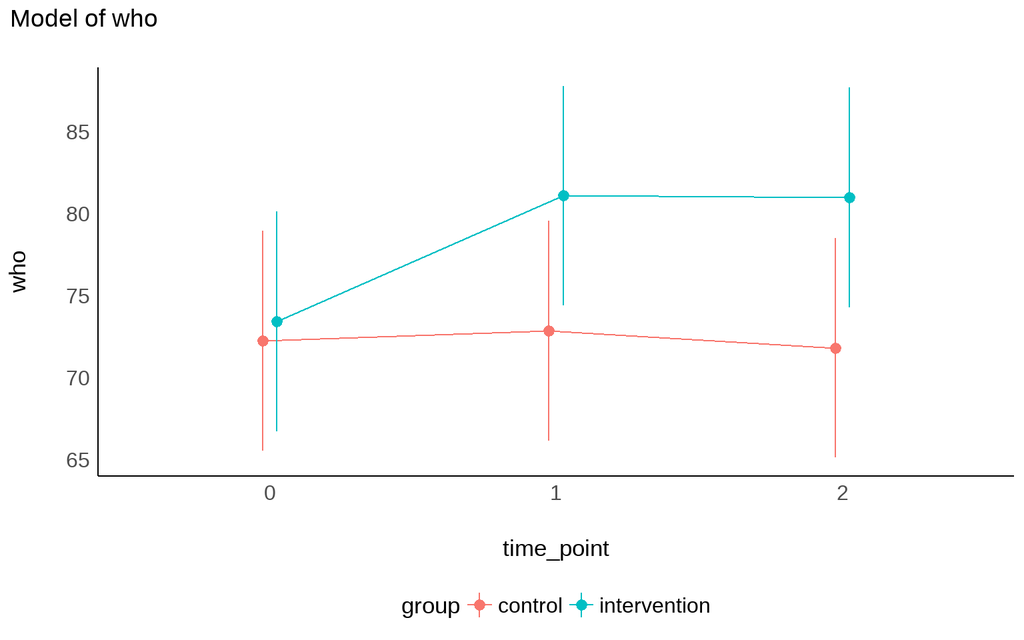

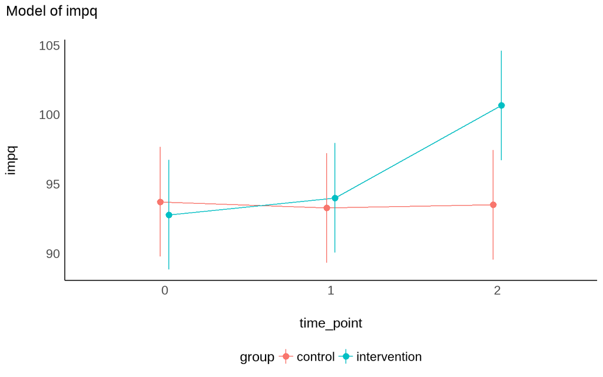

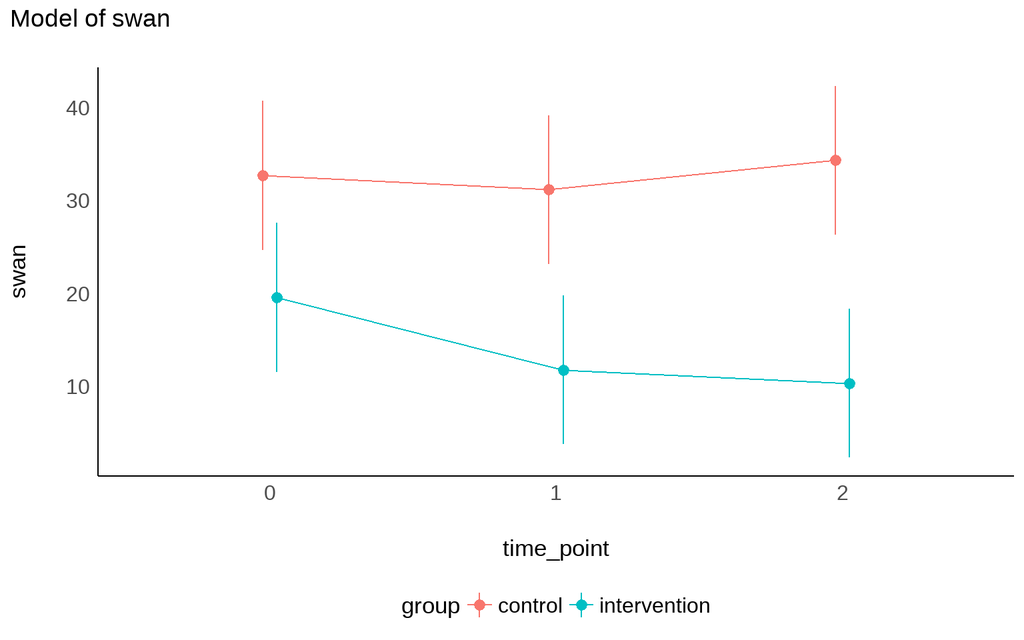